# Class05

Let’s make a plot with a straight line fit -i.e. a linear model and no standard error shown.

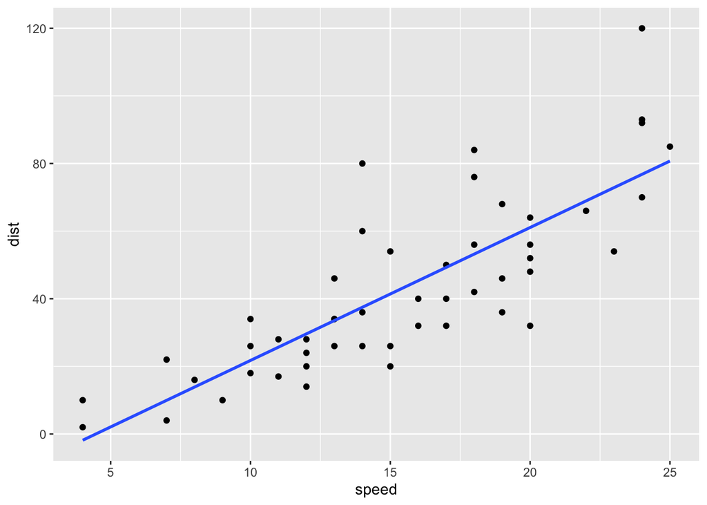

```r
ggplot(data=cars) +
  aes(x=speed, y=dist) +
  geom_point() +
  geom_smooth(se=FALSE, method="lm")
```

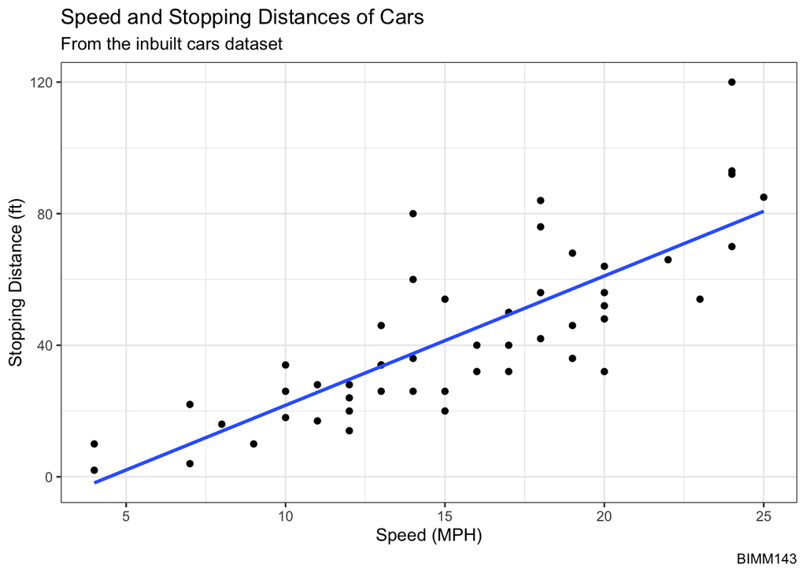

```r
ggplot(cars) +
  aes(x=speed, y=dist) +
  geom_point() +
  geom_smooth(se=FALSE, method="lm") +
  labs(title="Speed and Stopping Distances of Cars",
       subtitle= "From the inbuilt cars dataset",
       caption="BIMM143",
       x="Speed (MPH)",
       y="Stopping Distance (ft)") +
  theme_bw()
```

## A more complicated plot

Let’s plot some gene expression data. The code bbelow reads the results on differential expression analysis where a new anti-viral drug is being tested.

```r
url <- "https://bioboot.github.io/bimm143_S20/class-material/up_down_expression.txt"
genes <- read.delim(url)
head(genes)
```

```
##         Gene Condition1 Condition2      State
## 1      A4GNT -3.6808610 -3.4401355 unchanging
## 2       AAAS  4.5479580  4.3864126 unchanging
## 3      AASDH  3.7190695  3.4787276 unchanging
## 4       AATF  5.0784720  5.0151916 unchanging
## 5       AATK  0.4711421  0.5598642 unchanging
## 6 AB015752.4 -3.6808610 -3.5921390 unchanging
```

> Q. How many genes are in this dataset?

```r
nrow(genes)
```

```
## [1] 5196
```

> Q. How can we summarize that last column - the “State” column?

```r
table(genes$State)
```

```
##
##       down unchanging         up
##         72       4997        127
```

> Q. Fraction of total

```r
round( table(genes$State)/nrow(genes) * 100, 2 )
```

```
##
##       down unchanging         up
##       1.39      96.17       2.44
```

```r
p <- ggplot(genes) +
  aes(x=Condition1, y=Condition2, col=State) +
  geom_point()
```

I can know just call `p` when I want to plot or add to it

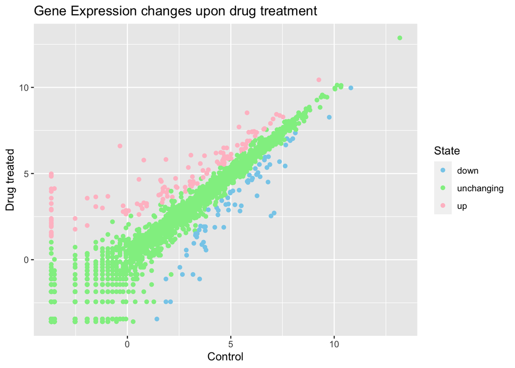

```r
p+ labs(title= "Gene Expression changes upon drug treatment",
        x="Control", y="Drug treated") +
  scale_color_manual( values=c("skyblue", "lightgreen","pink" ))
```

## Going further

Here I read a slightly larger dataset

```r
# File location online
url <- "https://raw.githubusercontent.com/jennybc/gapminder/master/inst/extdata/gapminder.tsv"

gapminder <- read.delim(url)
head(gapminder)
```

```
##       country continent year lifeExp      pop gdpPercap
## 1 Afghanistan      Asia 1952  28.801  8425333  779.4453
## 2 Afghanistan      Asia 1957  30.332  9240934  820.8530
## 3 Afghanistan      Asia 1962  31.997 10267083  853.1007
## 4 Afghanistan      Asia 1967  34.020 11537966  836.1971
## 5 Afghanistan      Asia 1972  36.088 13079460  739.9811
## 6 Afghanistan      Asia 1977  38.438 14880372  786.1134
```

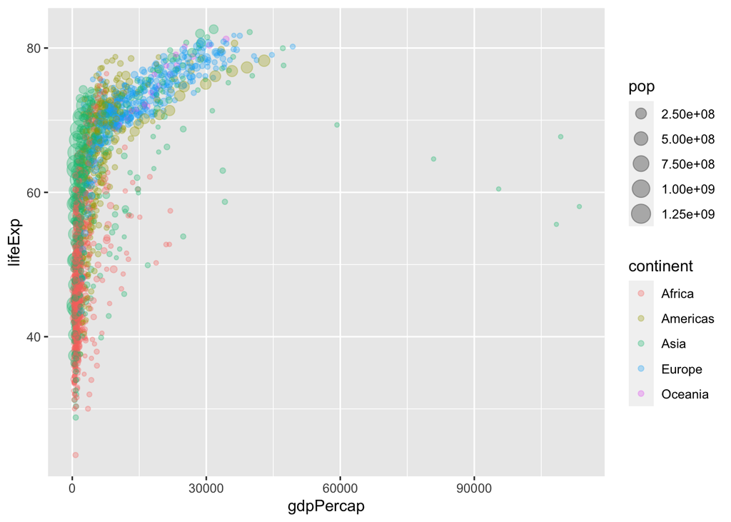

```r
ggplot(gapminder) +
  aes(x=gdpPercap, y=lifeExp, color=continent, size=pop)+
  geom_point(alpha=0.3)
```

A very useful layer to add sometimes is for “faceting”

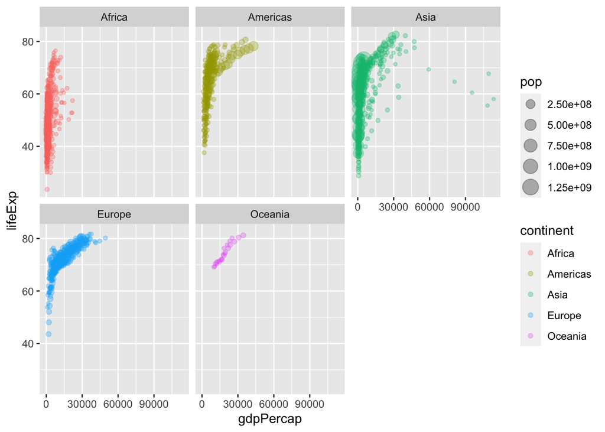

```r
ggplot(gapminder) +
  aes(x=gdpPercap, y=lifeExp, color=continent, size=pop)+
  geom_point(alpha=0.3) +
  facet_wrap(~continent)
```